# Explore Wine data by Zhongwei Teng

# Univariate Plots Section

```
## 'data.frame':    1599 obs. of  13 variables:
##  $ X                   : int  1 2 3 4 5 6 7 8 9 10 ...
##  $ fixed.acidity       : num  7.4 7.8 7.8 11.2 7.4 7.4 7.9 7.3 7.8 7.5 ...
##  $ volatile.acidity    : num  0.7 0.88 0.76 0.28 0.7 0.66 0.6 0.65 0.58 0.5 ...
##  $ citric.acid         : num  0 0 0.04 0.56 0 0 0.06 0 0.02 0.36 ...
##  $ residual.sugar      : num  1.9 2.6 2.3 1.9 1.9 1.8 1.6 1.2 2 6.1 ...
##  $ chlorides           : num  0.076 0.098 0.092 0.075 0.076 0.075 0.069 0.065 0.073 0.071 ...
##  $ free.sulfur.dioxide : num  11 25 15 17 11 13 15 15 9 17 ...
##  $ total.sulfur.dioxide: num  34 67 54 60 34 40 59 21 18 102 ...
##  $ density             : num  0.998 0.997 0.997 0.998 0.998 ...
##  $ pH                  : num  3.51 3.2 3.26 3.16 3.51 3.51 3.3 3.39 3.36 3.35 ...
##  $ sulphates           : num  0.56 0.68 0.65 0.58 0.56 0.56 0.46 0.47 0.57 0.8 ...
##  $ alcohol             : num  9.4 9.8 9.8 9.8 9.4 9.4 9.4 10 9.5 10.5 ...
##  $ quality             : int  5 5 5 6 5 5 5 7 7 5 ...
```

```
##        X          fixed.acidity   volatile.acidity  citric.acid
##  Min.   :   1.0   Min.   : 4.60   Min.   :0.1200   Min.   :0.000
##  1st Qu.: 400.5   1st Qu.: 7.10   1st Qu.:0.3900   1st Qu.:0.090
##  Median : 800.0   Median : 7.90   Median :0.5200   Median :0.260
##  Mean   : 800.0   Mean   : 8.32   Mean   :0.5278   Mean   :0.271
##  3rd Qu.:1199.5   3rd Qu.: 9.20   3rd Qu.:0.6400   3rd Qu.:0.420
##  Max.   :1599.0   Max.   :15.90   Max.   :1.5800   Max.   :1.000
##  residual.sugar     chlorides       free.sulfur.dioxide
##  Min.   : 0.900   Min.   :0.01200   Min.   : 1.00
##  1st Qu.: 1.900   1st Qu.:0.07000   1st Qu.: 7.00
##  Median : 2.200   Median :0.07900   Median :14.00
##  Mean   : 2.539   Mean   :0.08747   Mean   :15.87
##  3rd Qu.: 2.600   3rd Qu.:0.09000   3rd Qu.:21.00
##  Max.   :15.500   Max.   :0.61100   Max.   :72.00
##  total.sulfur.dioxide    density             pH          sulphates
##  Min.   :  6.00       Min.   :0.9901   Min.   :2.740   Min.   :0.3300
##  1st Qu.: 22.00       1st Qu.:0.9956   1st Qu.:3.210   1st Qu.:0.5500
##  Median : 38.00       Median :0.9968   Median :3.310   Median :0.6200
##  Mean   : 46.47       Mean   :0.9967   Mean   :3.311   Mean   :0.6581
##  3rd Qu.: 62.00       3rd Qu.:0.9978   3rd Qu.:3.400   3rd Qu.:0.7300
##  Max.   :289.00       Max.   :1.0037   Max.   :4.010   Max.   :2.0000
##     alcohol         quality
##  Min.   : 8.40   Min.   :3.000
##  1st Qu.: 9.50   1st Qu.:5.000
##  Median :10.20   Median :6.000
##  Mean   :10.42   Mean   :5.636
##  3rd Qu.:11.10   3rd Qu.:6.000
##  Max.   :14.90   Max.   :8.000
```

Our dataset contatin 1599 observations and 13 variables. ‘x’ is the index of different observation.

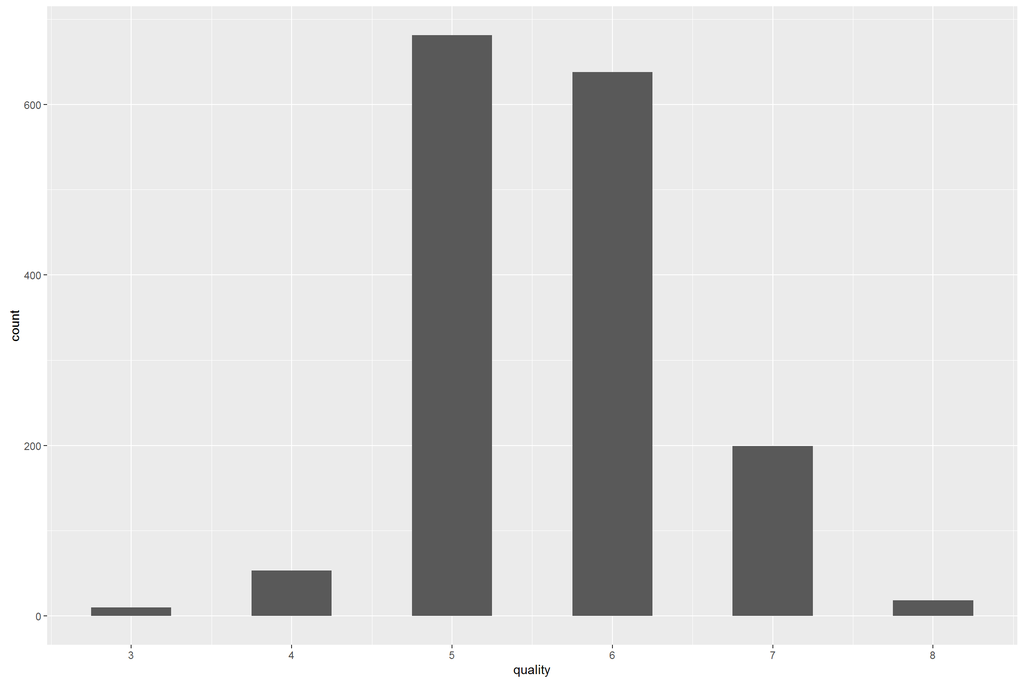

```
##
##   3   4   5   6   7   8
##  10  53 681 638 199  18
```

In this figure, we can see most wine’s quality range from 5 to 6. Only few of them are great or bad wine. We are curious about which element decide final quality.

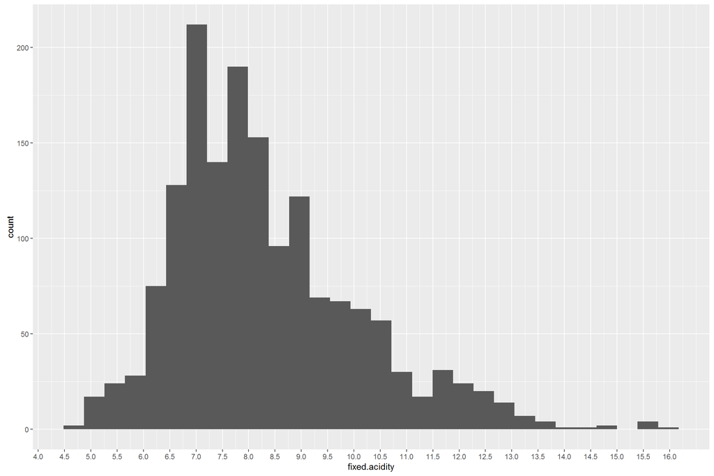

```
##    Min. 1st Qu.  Median    Mean 3rd Qu.    Max.
##    4.60    7.10    7.90    8.32    9.20   15.90
```

‘fixed.acidity’ obey norm distribution. It reach the peak near the 7.0. Most of them are 6.5-9.5.

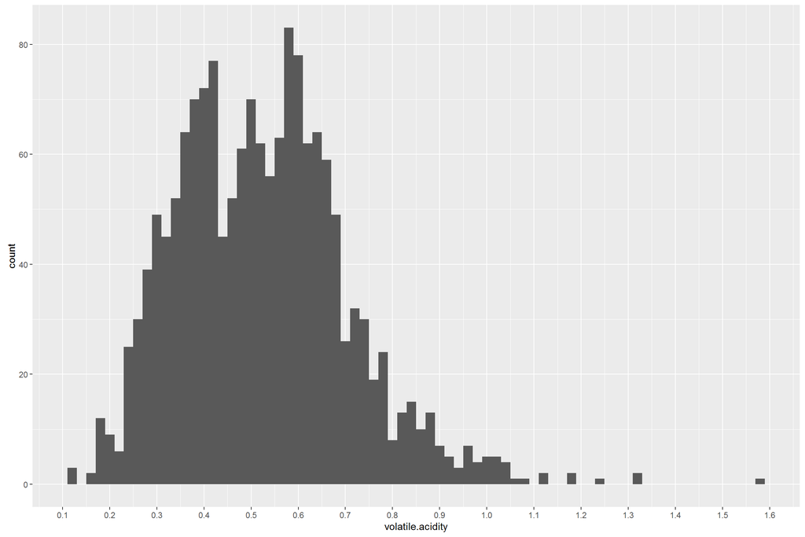

```
##    Min. 1st Qu.  Median    Mean 3rd Qu.    Max.
##  0.1200  0.3900  0.5200  0.5278  0.6400  1.5800
```

For ‘volatile.acidity’, most wines locate near 0.3-0.8. It has two peaks near 0.4 and 0.6 and there is a valley near 0.45. Which reason cause this valley?

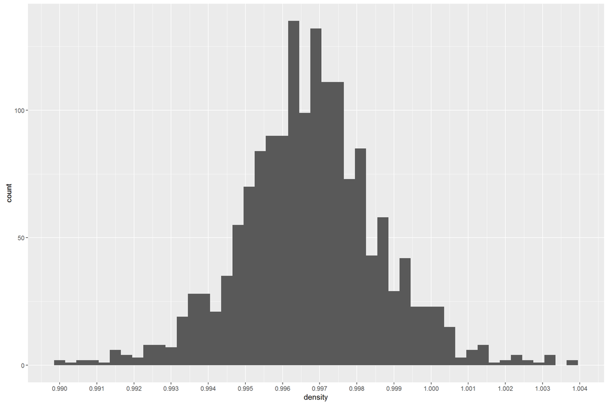

```
##    Min. 1st Qu.  Median    Mean 3rd Qu.    Max.
##  0.9901  0.9956  0.9968  0.9967  0.9978  1.0040
```

It seems like ‘density’ obeys norm distribution. The value aggregates near the 0.995 to 0.998.

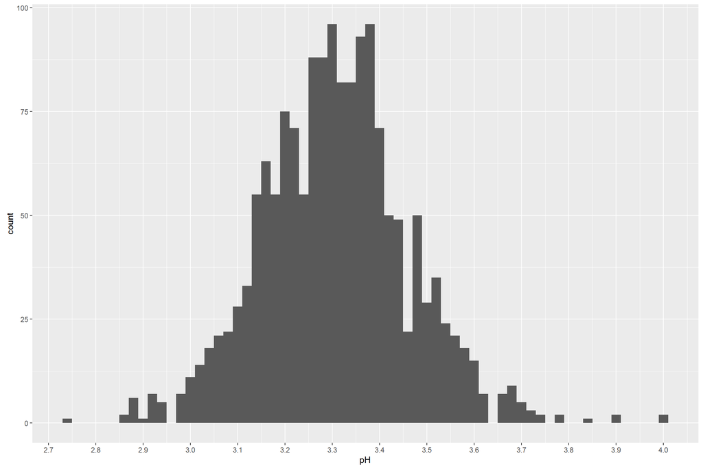

```
##    Min. 1st Qu.  Median    Mean 3rd Qu.    Max.
##   2.740   3.210   3.310   3.311   3.400   4.010
```

The pH value for most wine aggregate between 3.1 and 3.5. The peak occurs in 3.3.

Most of other features are long-tailed distribution. Thus we will tranform them using log or square root.

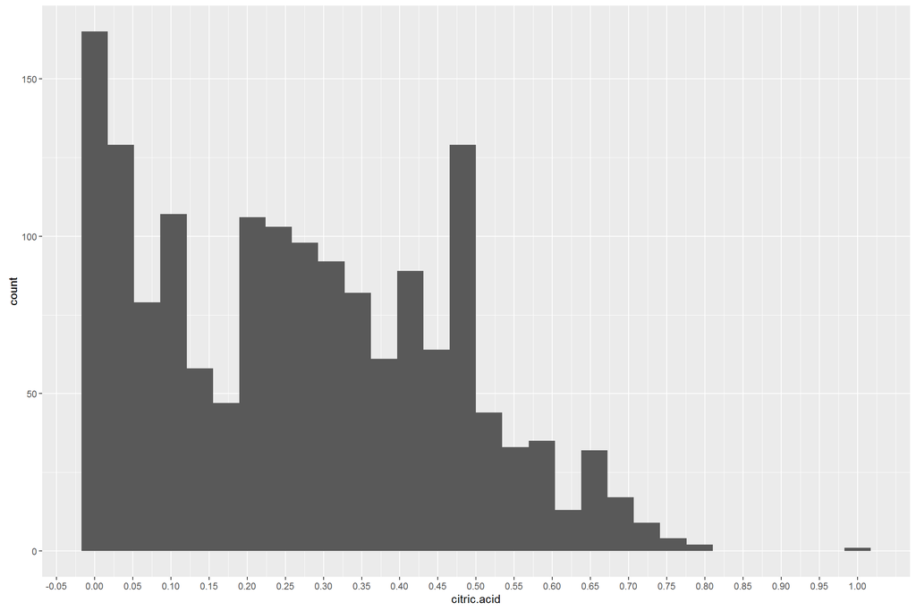

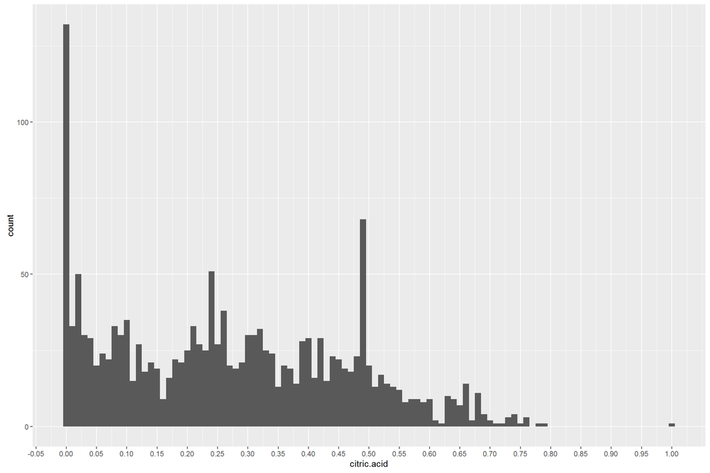

```
##    Min. 1st Qu.  Median    Mean 3rd Qu.    Max.
##   0.000   0.090   0.260   0.271   0.420   1.000
```

There two things we care about. This first is that we can find lots of wine’s ‘citric.acid’ can be zero. The second one is we can find a outlier whose value are near to 1. Does this ourlier have connection with bad or good quality?

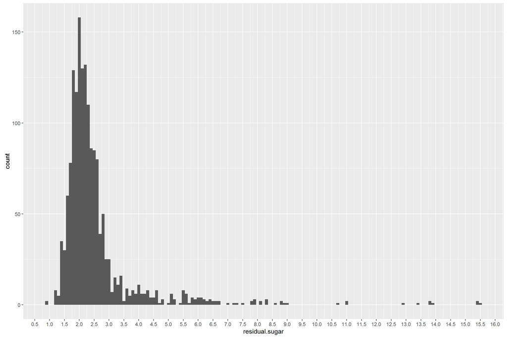

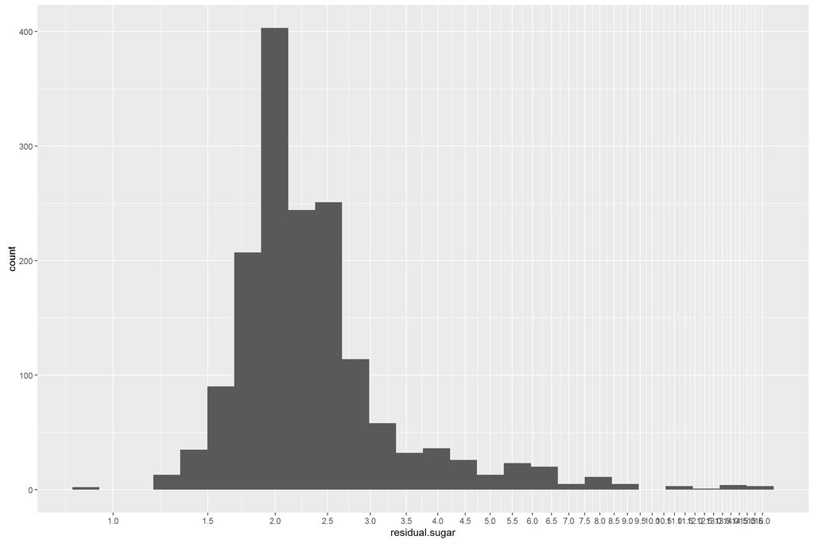

```
##    Min. 1st Qu.  Median    Mean 3rd Qu.    Max.
##   0.900   1.900   2.200   2.539   2.600  15.500
```

We can find there is a peak near residual.sugar=2. Most wine’s value of residual.sugar are in the range of 1.5 to 3.0. The whole figure tend to be right skewed, but both left side and right side have outliers.

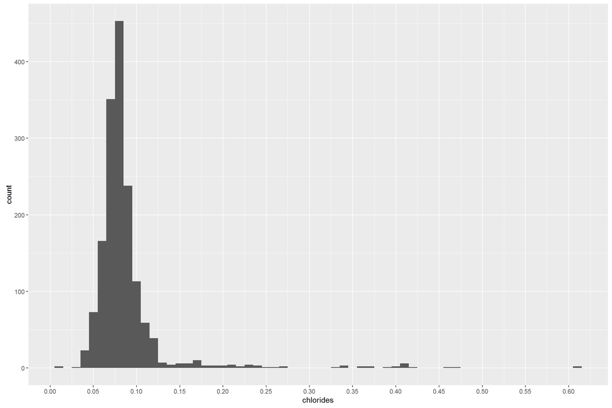

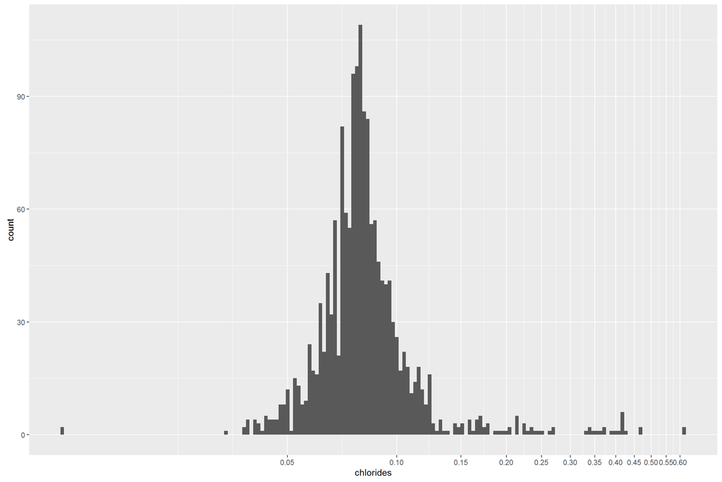

```
##    Min. 1st Qu.  Median    Mean 3rd Qu.    Max.
## 0.01200 0.07000 0.07900 0.08747 0.09000 0.61100
```

After we log the figure, the figure is symmetirc and the peak is 0.08. There also exists few higher values on the right side.

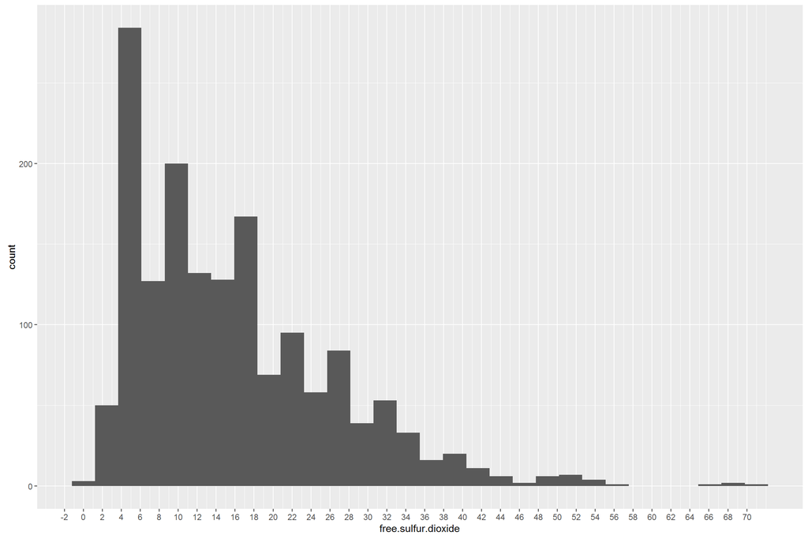

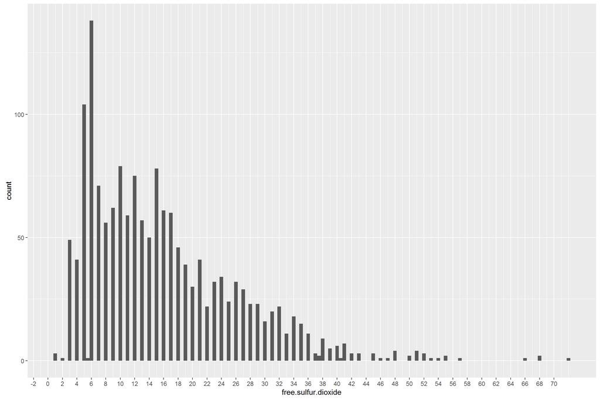

```
##    Min. 1st Qu.  Median    Mean 3rd Qu.    Max.
##    1.00    7.00   14.00   15.87   21.00   72.00
```

When we decrese the bin width, we find most wine’s value of free.sulfur.dioxide are integer. The distribution is right skewed. The peak is 6 and the outliers can be much higer than most wine.

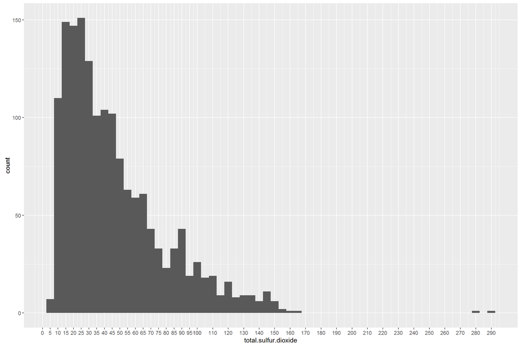

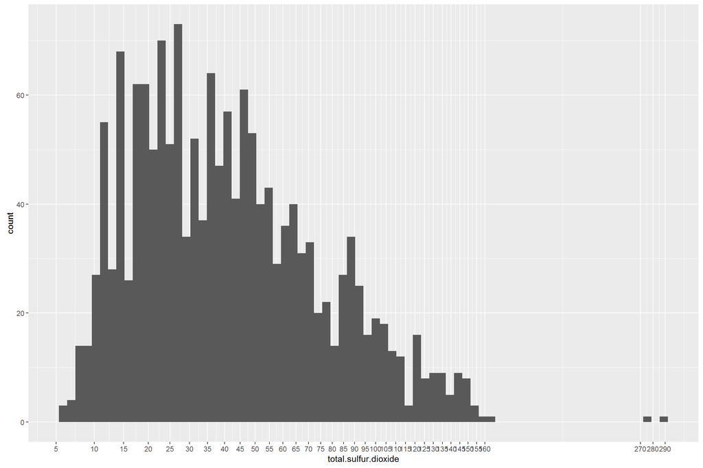

```
##    Min. 1st Qu.  Median    Mean 3rd Qu.    Max.
##    6.00   22.00   38.00   46.47   62.00  289.00
```

The distribution of total.sulfur.dioxide is a long-tailed graphic. When we transform it using ‘sqrt’, it shows that the rest of it tend to be norm distribution. For most wine, the value range from 0 to 160.

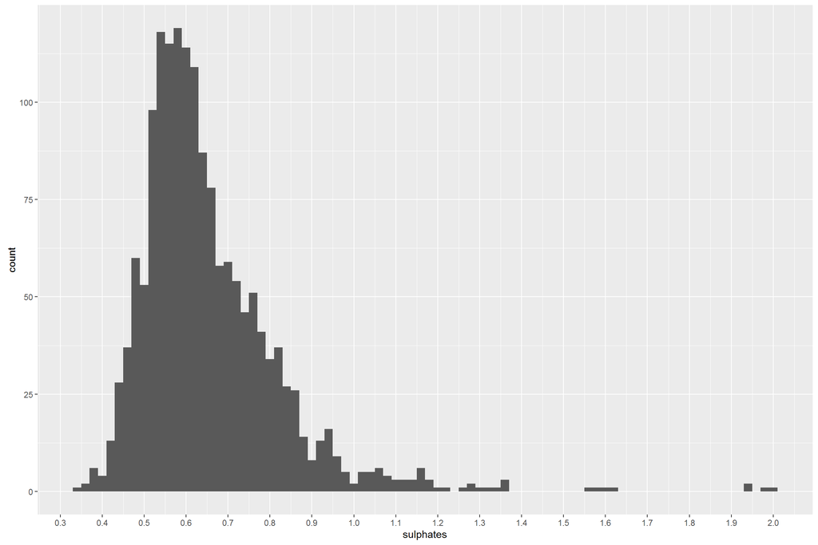

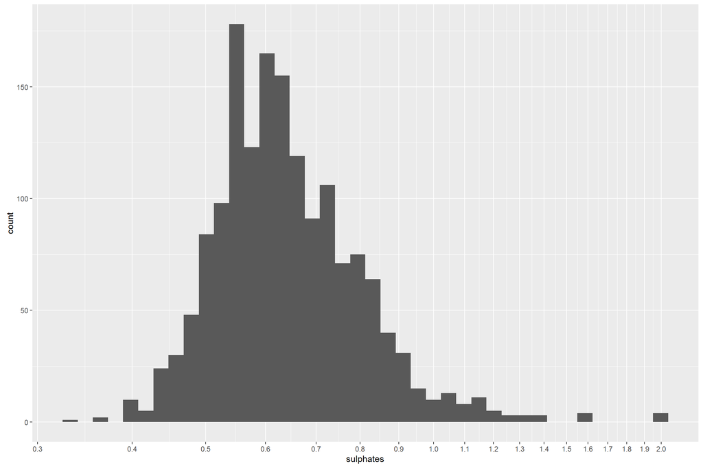

```
##    Min. 1st Qu.  Median    Mean 3rd Qu.    Max.
##  0.3300  0.5500  0.6200  0.6581  0.7300  2.0000
```

Similar with former one, after transforming it, the new graphics become norm distribution from long-tailed distribution and the peak is 0.55.

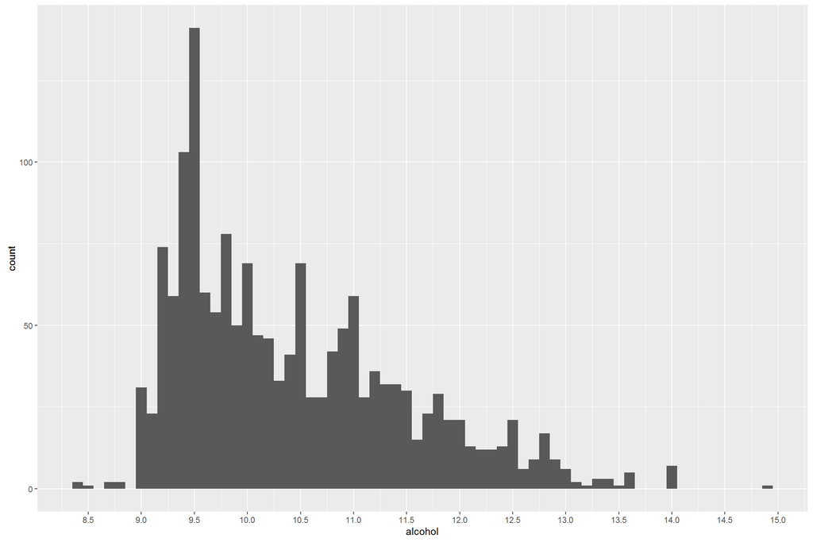

```
##    Min. 1st Qu.  Median    Mean 3rd Qu.    Max.
##    8.40    9.50   10.20   10.42   11.10   14.90
```

The graphic is right skewed, the peak value is 9.5 and the ourlier’s value is 15. The difference is relatively small. Most wine’s value of alcohol range from 9 to 12.

# Univariate Analysis

### What is/are the main feature(s) of interest in your dataset?

Considering the distribution of ‘quality’, we are interested in ‘fixed.acidity’, ‘volatile.acidity’, ‘density’, ‘pH’. I want to know which factor or combination decide the score of quality. I guess they may have higher influence to quality than others.

### What other features in the dataset do you think will help support your investigation into your feature(s) of interest?

I think ‘chlorides’,‘sulphates’, ‘residual.sugar’ also have influence to quality combined with former features. Since all of them have the similar distribution with ‘quality’.

### Did you create any new variables from existing variables in the dataset?

No. I’m not familiar with those features. I’m not sure if there any inner connection among those features. In this case, creating new features may not a good decision.

### Of the features you investigated, were there any unusual distributions? Did you perform any operations on the data to tidy, adjust, or change the form of the data? If so, why did you do this?

This dataset is tidy at beginning so I don’t do extra work. Basically, the distribution of these data can be divided into norm distribution and long-tailed distribution. For ‘chloride’, ‘sulphates’, ‘residual.sugar’, they are long-tailed data. After transforming them using ‘log10’ or ‘sqrt’, we find they are also similar with norm distribution.

# Bivariate Plots Section

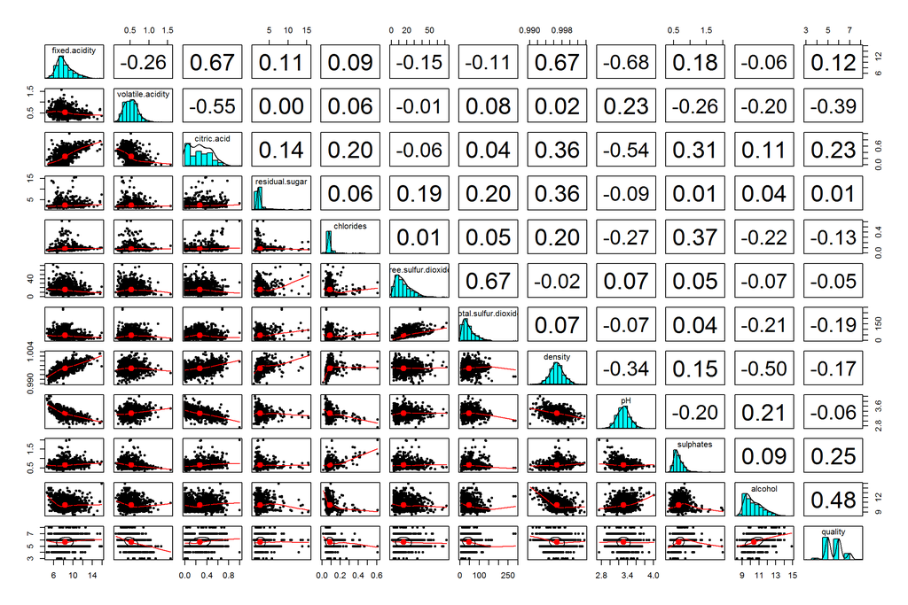

From the figure, only ‘volatile.acidity’ and ‘alcohol’ have strong correlation with ‘quality’. Furthermore, ‘density’ is correlated with ‘alcohol’ and ‘citric.acid’ is correlated with ‘volatile.acidity’. Thus we decide to investigate all those five features in the next part.

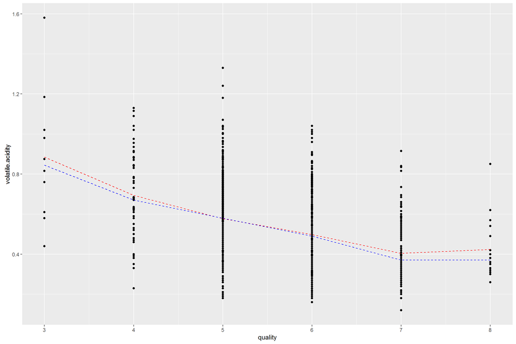

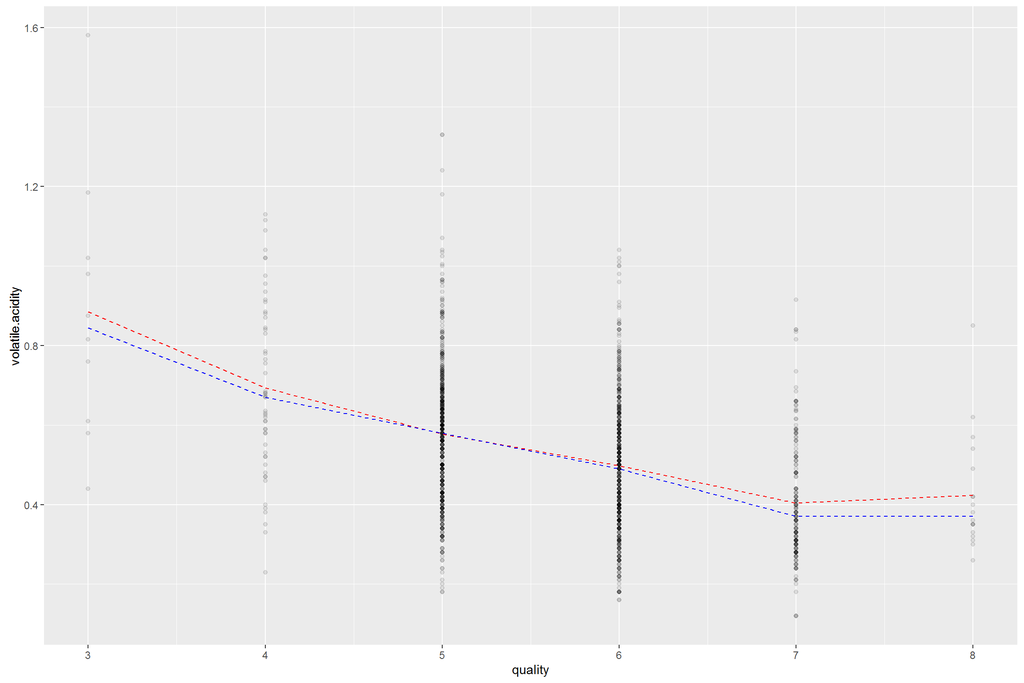

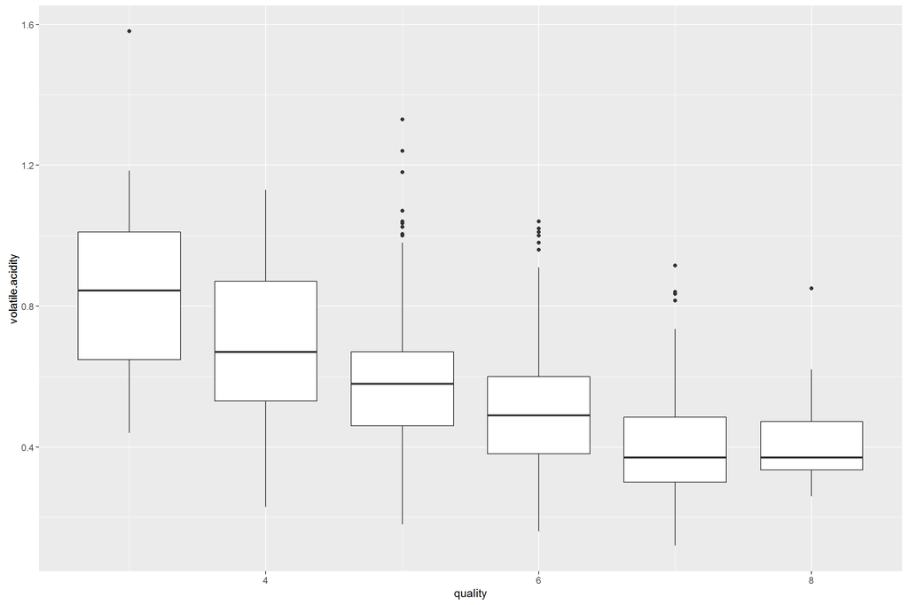

```
##
##  Pearson's product-moment correlation
##
## data:  quality and volatile.acidity
## t = -16.954, df = 1597, p-value < 2.2e-16
## alternative hypothesis: true correlation is not equal to 0
## 95 percent confidence interval:
##  -0.4313210 -0.3482032
## sample estimates:
##        cor
## -0.3905578
```

```
## Source: local data frame [6 x 4]
##
##   quality volatile.acidity_mean volatile.acidity_median     n
##     (int)                 (dbl)                   (dbl) (int)
## 1       3             0.8845000                   0.845    10
## 2       4             0.6939623                   0.670    53
## 3       5             0.5770411                   0.580   681
## 4       6             0.4974843                   0.490   638
## 5       7             0.4039196                   0.370   199
## 6       8             0.4233333                   0.370    18
```

```
##     quality     volatile.acidity_mean volatile.acidity_median
##  Min.   :3.00   Min.   :0.4039        Min.   :0.3700
##  1st Qu.:4.25   1st Qu.:0.4419        1st Qu.:0.4000
##  Median :5.50   Median :0.5373        Median :0.5350
##  Mean   :5.50   Mean   :0.5800        Mean   :0.5542
##  3rd Qu.:6.75   3rd Qu.:0.6647        3rd Qu.:0.6475
##  Max.   :8.00   Max.   :0.8845        Max.   :0.8450
##        n
##  Min.   : 10.00
##  1st Qu.: 26.75
##  Median :126.00
##  Mean   :266.50
##  3rd Qu.:528.25
##  Max.   :681.00
```

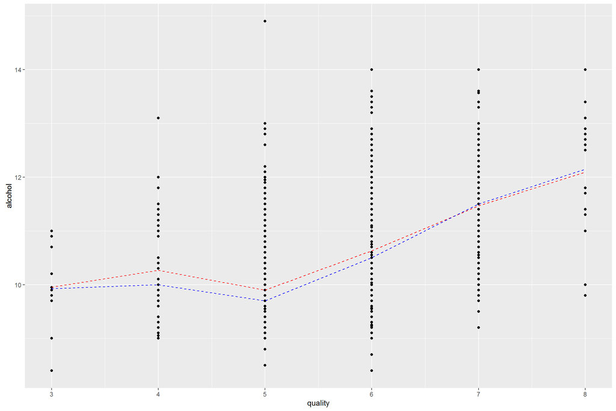

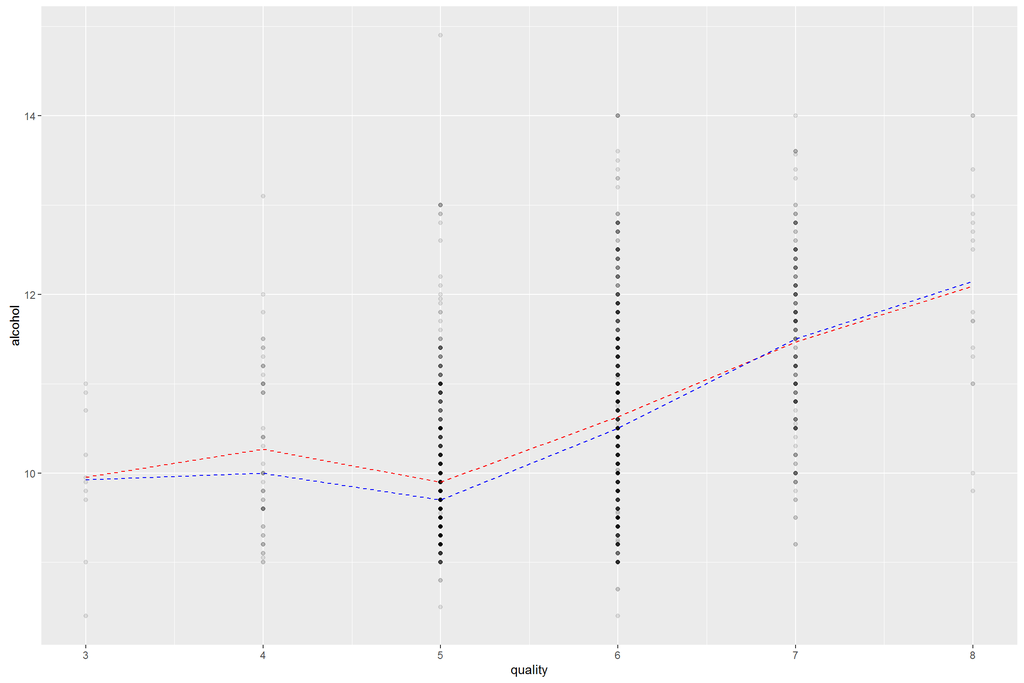

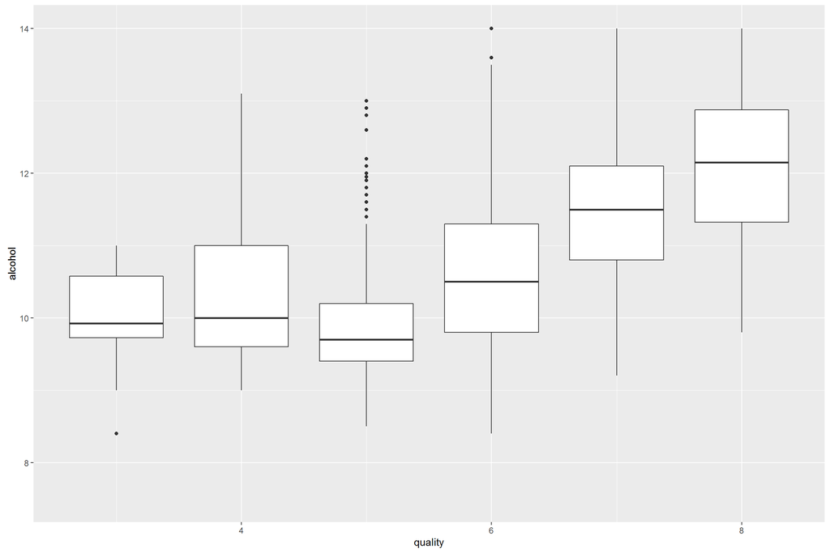

```
##
##  Pearson's product-moment correlation
##
## data:  quality and alcohol
## t = 21.639, df = 1597, p-value < 2.2e-16
## alternative hypothesis: true correlation is not equal to 0
## 95 percent confidence interval:
##  0.4373540 0.5132081
## sample estimates:
##       cor
## 0.4761663
```

```
## Source: local data frame [6 x 4]
##
##   quality alcohol_mean alcohol.acidity_median     n
##     (int)        (dbl)                  (dbl) (int)
## 1       3     9.955000                  9.925    10
## 2       4    10.265094                 10.000    53
## 3       5     9.899706                  9.700   681
## 4       6    10.629519                 10.500   638
## 5       7    11.465913                 11.500   199
## 6       8    12.094444                 12.150    18
```

```
##     quality      alcohol_mean   alcohol.acidity_median       n
##  Min.   :3.00   Min.   : 9.90   Min.   : 9.700         Min.   : 10.00
##  1st Qu.:4.25   1st Qu.:10.03   1st Qu.: 9.944         1st Qu.: 26.75
##  Median :5.50   Median :10.45   Median :10.250         Median :126.00
##  Mean   :5.50   Mean   :10.72   Mean   :10.629         Mean   :266.50
##  3rd Qu.:6.75   3rd Qu.:11.26   3rd Qu.:11.250         3rd Qu.:528.25
##  Max.   :8.00   Max.   :12.09   Max.   :12.150         Max.   :681.00
```

Even though there is a small fluctuation at beginning, we can see our statistics of alcohol increase when quality increase. The correlation between these two features is clear.

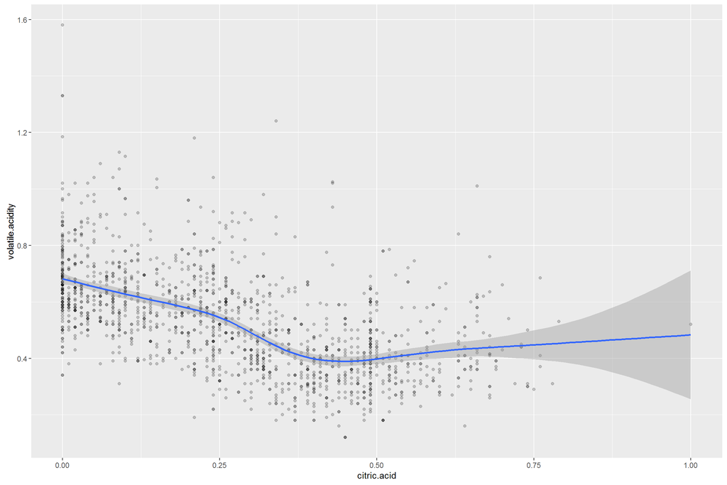

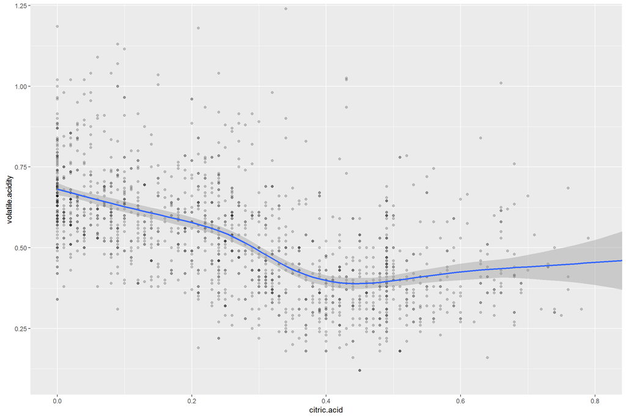

```
##
##  Pearson's product-moment correlation
##
## data:  wine$volatile.acidity and wine$citric.acid
## t = -26.489, df = 1597, p-value < 2.2e-16
## alternative hypothesis: true correlation is not equal to 0
## 95 percent confidence interval:
##  -0.5856550 -0.5174902
## sample estimates:
##        cor
## -0.5524957
```

We notice that these two variable exist negative, non-linear relationship. When citric.acid reach 0.5, the volatile.acidity tends to be flat.

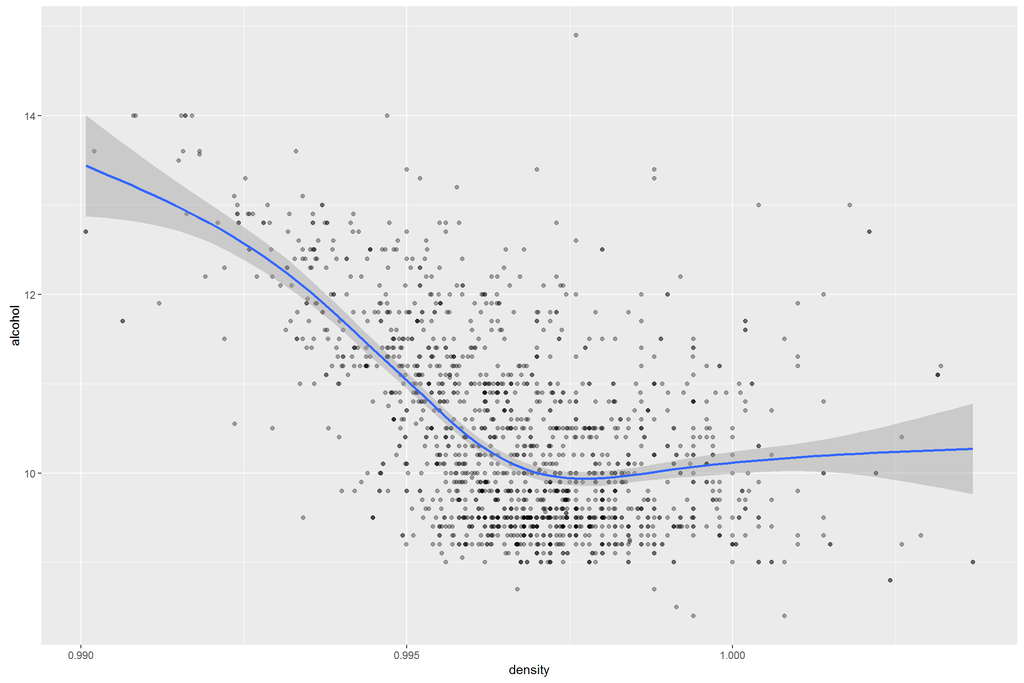

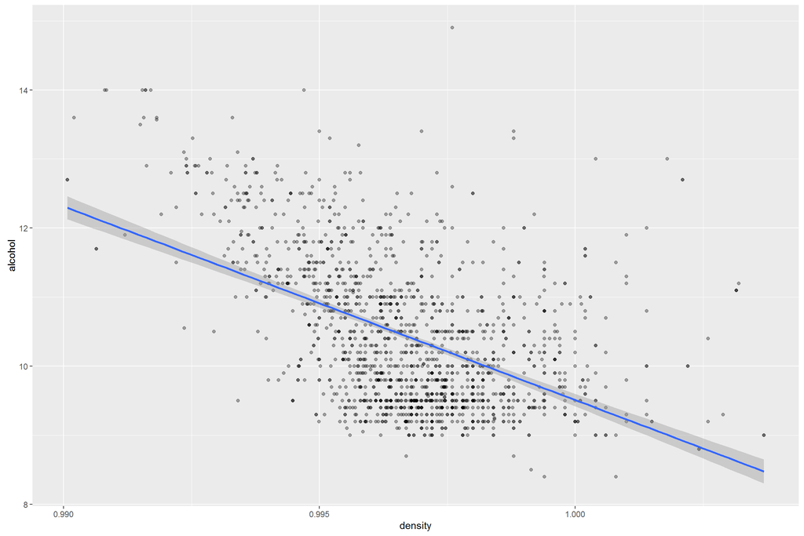

The plot shows lots of points have same value of alcohol and we also find lots of our points aggregate in the lower half of the figure. When desity increase, we find alcohol tends to decrease.

# Bivariate Analysis